# Healthcare Fraud Detection

```r
ScaledSum %>% arrange(ScTotMed) %>% top_n(10, -ScTotMed) #8/10 scaled total medicare lowest in California
```

```
## # A tibble: 10 x 7
##    DRGState                Count ScTotPay ScTotCov ScTotMed ScTotDis     SD
##    <chr>                   <int>    <dbl>    <dbl>    <dbl>    <dbl>  <dbl>
##  1 CA_871 - SEPTICEMIA OR~   273    -292.    149.     -330.    442.   8329.
##  2 CA_470 - MAJOR JOINT R~   235    -237.    105.     -288.    385.   5899.
##  3 CA_682 - RENAL FAILURE~   191    -231.    119.     -227.    -22.7 13394.
##  4 CA_481 - HIP & FEMUR P~   163    -186.     76.7    -212.    -39.2  7503.
##  5 CA_280 - ACUTE MYOCARD~   170    -192.    101.     -207.    -55.4 11895.
##  6 CA_064 - INTRACRANIAL ~   165    -178.     75.0    -204.    -35.2  8610.
##  7 CA_177 - RESPIRATORY I~   172    -172.     31.9    -201.    -23.6  6648.
##  8 TX_208 - RESPIRATORY S~   149    -173.    112.     -194.    -21.4  7235.
##  9 CA_377 - G.I. HEMORRHA~   158    -181.     96.7    -190.    -58.5  8631.
## 10 FL_208 - RESPIRATORY S~   138    -166.    121.     -188.    -13.2  7485.
```

```r
ScaledSum %>% arrange(desc(ScTotDis)) %>% top_n(10, ScTotDis) #6/10 DRG titles are major around relatively populous states
```

```
## # A tibble: 10 x 7
##    DRGState                Count ScTotPay ScTotCov ScTotMed ScTotDis     SD
##    <chr>                   <int>    <dbl>    <dbl>    <dbl>    <dbl>  <dbl>
##  1 FL_470 - MAJOR JOINT R~   151   -200.     167.    -131.      460.  8290.
##  2 CA_871 - SEPTICEMIA OR~   273   -292.     149.    -330.      442.  8329.
##  3 TX_470 - MAJOR JOINT R~   224   -282.     200.    -187.      401.  7869.
##  4 CA_470 - MAJOR JOINT R~   235   -237.     105.    -288.      385.  5899.
##  5 NY_871 - SEPTICEMIA OR~   151   -167.      48.0   -154.      304. 20949.
##  6 IL_470 - MAJOR JOINT R~   110   -129.     105.    -150.      301.  7545.
##  7 FL_392 - ESOPHAGITIS, ~   165    -23.6    -12.3    -68.4     279. 16053.
##  8 TX_871 - SEPTICEMIA OR~   216   -287.     147.    -155.      272. 24756.
##  9 NY_470 - MAJOR JOINT R~   141   -156.      70.3   -155.      261.  9986.
## 10 MI_470 - MAJOR JOINT R~    89   -107.      37.1   -119.      255.  6496.
```

```r
ScaledSum %>% arrange(ScTotDis) %>% top_n(10, -ScTotDis) #10/10 lowest scaled discharges in California
```

```
## # A tibble: 10 x 7
##    DRGState                Count ScTotPay ScTotCov ScTotMed ScTotDis     SD
##    <chr>                   <int>    <dbl>    <dbl>    <dbl>    <dbl>  <dbl>
##  1 CA_638 - DIABETES W CC    160   135.       72.4    114.     -69.4 27891.
##  2 CA_389 - G.I. OBSTRUCT~   153   121.       92.7    126.     -60.9 39016.
##  3 CA_195 - SIMPLE PNEUMO~   178    85.2      59.5     46.0    -59.3 19008.
##  4 CA_377 - G.I. HEMORRHA~   158  -181.       96.7   -190.     -58.5  8631.
##  5 CA_394 - OTHER DIGESTI~   143    93.6     106.     113.     -58.1 49712.
##  6 CA_293 - HEART FAILURE~   183    77.8      38.7     58.4    -58.0 22542.
##  7 CA_101 - SEIZURES W/O ~   134    81.5      50.6     81.6    -56.9 27833.
##  8 CA_391 - ESOPHAGITIS, ~   142     9.25    103.      68.1    -56.5 62617.
##  9 CA_280 - ACUTE MYOCARD~   170  -192.      101.    -207.     -55.4 11895.
## 10 CA_689 - KIDNEY & URIN~   175    18.7     128.      89.9    -54.8 62547.
```

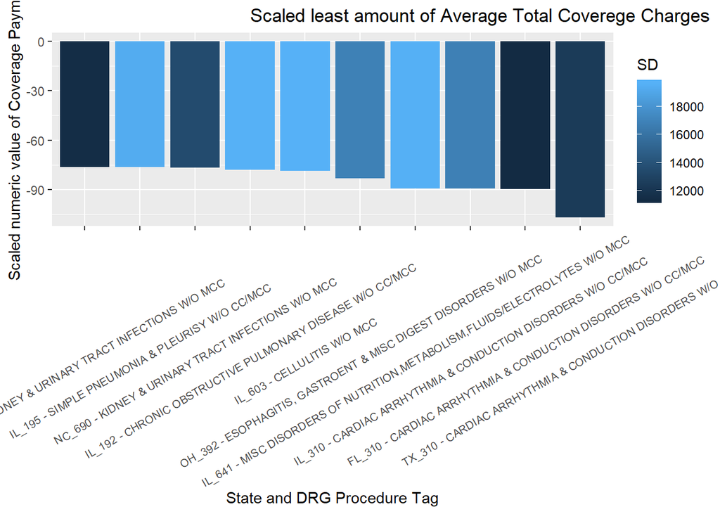

```r
map <- ScaledSum %>% arrange(ScTotCov)
map <- map[1:10,]

ggplot(data=map, aes(x=reorder(DRGState, -ScTotCov), y=ScTotCov, fill = SD)) +
  geom_bar(position="dodge",stat="identity") +
  ggtitle("                                     Scaled least amount of Average Total Coverege Charges") +
  ylab('Scaled numeric value of Coverage Payment') +
  xlab('State and DRG Procedure Tag') +
  theme(axis.text.x  = element_text(angle=30, vjust=0.5, size=8))
```

Conclusion

The scaling factor of total payments will be a very useful feature when it is time to create our fraud detection models. There is a high correlation between total payments and medicare payments, this seemed strange because in reading the description Total Payments were covered by the patients plan and out of pocket costs, with medicare covering specifically the subsidized portion. While the scaling factor did normalize the data, the summarization of it still showed a heavy population effect.

Lead